# Education and Unemployment: Analysis Across the Full Education Spectrum

### Nested Model Comparison

We fit a sequence of nested models to determine the appropriate level of complexity:

```r
# Fit nested model sequence
models_result <- fit_nested_models_to_cps_data(
  data_file = data_file,
  education_levels = education_levels,
  start_year = 2000,
  end_year = 2024
)

# Display model comparison
kable(
  models_result$comparison,
  digits = 2,
  caption = "Table 1: Nested Model Comparison (sorted by AIC)",
  col.names = c("Model", "AIC", "Deviance", "df Residual", "EDF", "R²", "Δ AIC")
)
```

Table 1: Nested Model Comparison (sorted by AIC)

| Model | AIC | Deviance | df Residual | EDF | R² | Δ AIC |
| --- | --- | --- | --- | --- | --- | --- |
| m6 | -10231.96 | 0.52 | 1863.68 | 61.32 | 0.74 | 0.00 |
| m4 | -10130.82 | 0.55 | 1869.97 | 55.03 | 0.73 | 101.14 |
| m5 | -9858.43 | 0.65 | 1900.97 | 24.03 | 0.68 | 373.53 |
| m3 | -9782.51 | 0.68 | 1906.04 | 18.96 | 0.66 | 449.46 |
| m2 | -9777.07 | 0.69 | 1909.23 | 15.77 | 0.66 | 454.90 |
| m1 | -9114.43 | 0.98 | 1918.00 | 7.00 | 0.52 | 1117.54 |
| m0 | -7702.61 | 2.06 | 1924.00 | 1.00 | 0.00 | 2529.35 |

**Model Descriptions:**

- **m0**: Intercept only (null model)
- **m1**: Education-specific intercepts
- **m2**: Education + shared smooth trend
- **m3**: Education + shared trend + shared seasonality
- **m4**: Education-specific trends + shared seasonality
- **m5**: Shared trend + education-specific seasonality
- **m6**: Fully saturated (education-specific trends + seasonality)

**Selected Model:** m6 (lowest AIC)

### Model Validation

Comprehensive diagnostic checks on the best-fitting model:

```r
# Get best model
best_model <- models_result$models[[models_result$best_model]]
data_for_validation <- models_result$data

# Run comprehensive validation for exploratory analysis on real data
validation <- validate_gam_model(
  model = best_model,
  data = data_for_validation,
  validation_type = "exploratory",
  verbose = FALSE
)

# Print validation summary
print(validation)
```

```
=== GAM Model Validation Report ===

Validation Type: EXPLORATORY
Overall Status: ✗ FAILED

Convergence:
   Model converged successfully in 1 iterations

Model Fit:
  R-squared: 0.741
  Deviance explained: 74.9%
  Quality: good

Residual Diagnostics:
  Normality: ✗ (p = 0.000)
  Autocorrelation: ✗ (p = 0.000)
  Heteroscedasticity: ✗ (p = 0.000)

Concurvity:
  Max concurvity: 0.857
  ⚠ High concurvity detected

Effective Degrees of Freedom:
  Total EDF: 61.3
  EDF ratio: 2.9%
  Overfitting risk: low

Critical Issues:
   Significant autocorrelation detected; High concurvity detected among smooth terms

Warnings (informative):
   Non-normal residuals detected (use Q-Q plots to assess severity); Heteroscedasticity detected (GAMs are robust to moderate heteroscedasticity)

Recommendations:
   Review Q-Q plot - normality test may be overly sensitive with large samples; Consider adding AR terms or using gamm() for autocorrelation; Consider variance modeling if heteroscedasticity is severe; Consider reducing model complexity or removing redundant smooths
```

**Validation Status**

**Overall validation:** ✗ FAILED

All diagnostic checks must pass before interpreting substantive results.

### Diagnostic Plots

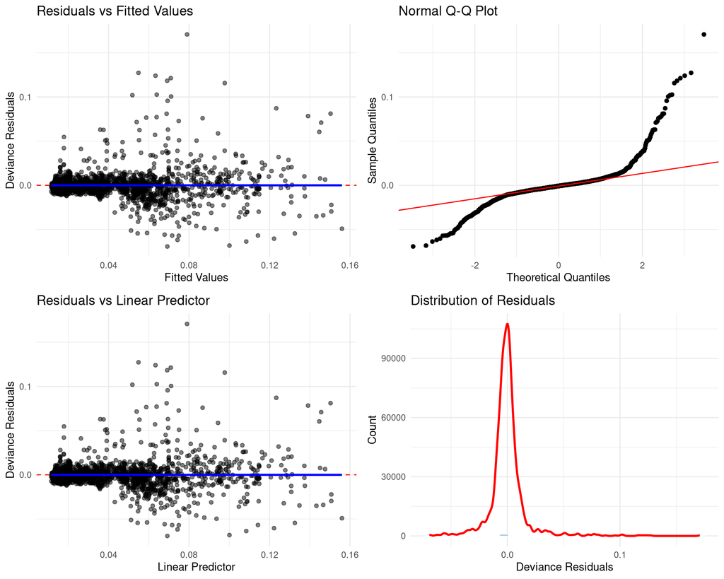

Figure 1: Standard GAM diagnostic plots

```r
plots <- create_diagnostic_plots(best_model)

# Arrange in 2x2 grid
gridExtra::grid.arrange(
  plots$residuals_vs_fitted,
  plots$qq_plot,
  plots$residuals_vs_linear_predictor,
  plots$residuals_histogram,
  ncol = 2
)
```

**Interpretation:**

- **Residuals vs Fitted**: Should show random scatter around zero (no patterns)
- **Q-Q Plot**: Points should follow the diagonal line (normality)
- **Residuals vs Linear Predictor**: Should show constant variance
- **Histogram**: Should be approximately normal

## Results

### Comprehensive Analysis

```r
# Run complete analysis pipeline
analysis <- analyze_cps_unemployment_by_education(
  data_file = data_file,
  education_levels = education_levels,
  start_year = 2000,
  end_year = 2024,
  save_models = FALSE,
  save_results = FALSE
)
```

```r
# Define color palette for all 7 education levels
# Using ColorBrewer-inspired palette for color-blind accessibility
education_colors <- c(
  "less_than_hs" = "#8C510A",   # Brown
  "high_school" = "#D8B365",     # Tan
  "some_college" = "#F6E8C3",    # Light tan
  "bachelors" = "#C7EAE5",       # Light teal
  "masters" = "#5AB4AC",         # Teal
  "professional" = "#01665E",    # Dark teal
  "phd" = "#003C30"              # Very dark teal
)

education_labels <- c(
  "less_than_hs" = "Less than HS",
  "high_school" = "High School",
  "some_college" = "Some College",
  "bachelors" = "Bachelor's",
  "masters" = "Master's",
  "professional" = "Professional",
  "phd" = "PhD"
)
```

### Time Series of Unemployment Rates

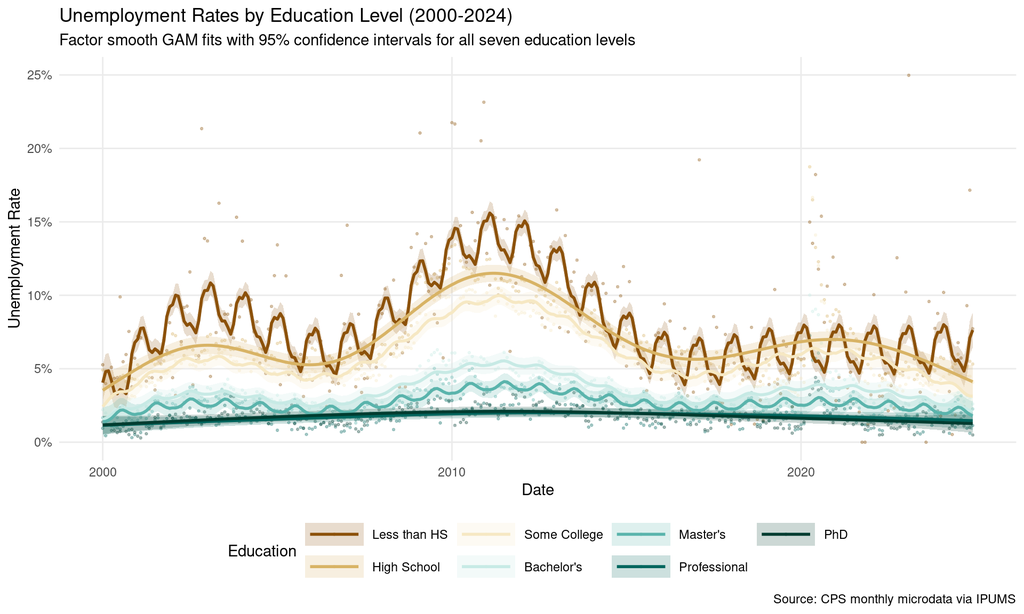

Figure 2: Unemployment rates by education level with model fits and 95% confidence intervals

```r
viz_data <- analysis$visualization_data

ggplot() +
  # Observed data
  geom_point(
    data = viz_data$observed,
    aes(x = date, y = unemployment_rate, color = education),
    alpha = 0.3,
    size = 0.5
  ) +
  # Fitted values with confidence intervals
  geom_ribbon(
    data = viz_data$fitted,
    aes(x = date, ymin = lower, ymax = upper, fill = education),
    alpha = 0.2
  ) +
  geom_line(
    data = viz_data$fitted,
    aes(x = date, y = fitted, color = education),
    linewidth = 1
  ) +
  scale_color_manual(
    values = education_colors,
    labels = education_labels,
    name = "Education"
  ) +
  scale_fill_manual(
    values = education_colors,
    labels = education_labels,
    name = "Education"
  ) +
  scale_y_continuous(labels = scales::percent_format()) +
  labs(
    title = "Unemployment Rates by Education Level (2000-2024)",
    subtitle = "Factor smooth GAM fits with 95% confidence intervals for all seven education levels",
    x = "Date",
    y = "Unemployment Rate",
    caption = "Source: CPS monthly microdata via IPUMS"
  ) +
  theme_minimal() +
  theme(
    legend.position = "bottom",
    panel.grid.minor = element_blank(),
    legend.key.width = unit(1.5, "cm")
  ) +
  guides(color = guide_legend(nrow = 2))
```